# The Pantanal fire, Brazil

## It’s a Data Science Workflow

With the extreme drought driven by the strong El Niño of 2023, forest fires broke records in the Pantanal. In the first 20 days of November, 2023, the biome has already had 3,957 fire outbreaks, around nine times higher than the average for the month in the last 25 years, which is 442 hot spots. The data are from the Queimadas Program, from the National Institute for Space Research (INPE). [WWF](https://www.wwf.org.br/?87282/Pantanal-has-record-number-of-fire-outbreaks-in-the-first-20-days-of-November)

## Observing vegetation health from space

We will look at the destruction and recovery of vegetation using NDVI (Normalized Difference Vegetation Index). How does it work? First, we need to learn about spectral reflectance signatures.

Resources:

- [SEOS Project](https://seos-project.eu/remotesensing/images/Reflexionskurven.jpg)
- [Healthy leaves reflect a lot of NIR radiation compared to dead or stressed leaves](https://github.com/px39n/Awesome-Vegetation-Index)
- [earthdatascience.org](https://www.earthdatascience.org/courses/use-data-open-source-python/multispectral-remote-sensing/vegetation-indices-in-python/calculate-NDVI-python/)
- [USGS](https://www.usgs.gov/landsat-missions/landsat-surface-reflectance-derived-spectral-indices)

```python
# Quietly install the development version of the earthpy package
!pip install -q git+https://github.com/earthlab/earthpy@apppears
```

```python
import getpass
import json
import os
import pathlib
import matplotlib.pyplot as plt
from glob import glob
import pandas as pd
import geopandas as gpd
import xyzservices.providers as xyz
import earthpy.appeears as eaapp
import hvplot.pandas
import hvplot.xarray
import rioxarray as rxr
import xarray as xr
```

> **Task**

> Creating a directory for data

```python
# data_dir = os.path.join(pathlib.Path.home(), 'data')
data_dir = 'data'
# Make the data directory
os.makedirs(data_dir, exist_ok=True)
data_dir
```

```
'data'
```

## Study Area: Pantanal Boundary

> **Task**
> - **Download** Pantanal bourdary shapefile from https://terrabrasilis.dpi.inpe.br/downloads/ to your local computer
> - **Look for** "Limite do Bioma Pantanal - Shapefile"
> - **Upload** the shapefile files to the notebook environment
> - **Load the data into Python** using the `geopandas` library
> - **Call** the data at the end of the cell for testing.

```python
#url = ("/workspaces/shortcourse-02-vegetation-Garcia-INPE/PantanalLimits/biome_border.shp")
url = ("/Users/jrmgarcia/ProjData/Shapefiles/Pantanal/biome_border.shp")
gdf_pant = gpd.read_file(url)
gdf_pant
```

|  | id | bioma | cd_bioma | area_km | geometry |
| --- | --- | --- | --- | --- | --- |
| 0 | 6 | Pantanal | 6 | 150961.061976 | POLYGON ((-57.75946 -15.72779, -57.75659 -15.7... |

```python
type(gdf_pant)
```

```
geopandas.geodataframe.GeoDataFrame
```

### Site Map

> **Task**
> - Plot the Pantanal boundary on an interactive map
> - Make sure to add a title
> - Add ESRI World Imagery as the basemap/background using the `tiles=...` parameter

```python
# Plot the Pantanal boundary
# Tiles basemap "NOT DATA AVAILABLE" message can occur due to zoom level
# Tiles' options:
# CartoDark, CartoLight, EsriImagery, EsriNatGeo, EsriReference,
# EsriStreet, EsriTerrain, EsriUSATopo, OSM, OpenTopoMap

#ax = gdf_pant.plot()
#ax.set_title('Pantanal area / Brazil')
#plt.show()

# HVPLOT + 700kB
gdf_pant.hvplot(
   title='Pantanal area / Brazil',
   tiles='CartoLight')
```

[output not shown]

## Exploring the AppEEARS API for NASA Earthdata access

> **Task**
> - Enter your NASA Earthdata username and password when prompted
> - Replace the start and end dates in the task parameters. Download data from July, when greenery is at its peak in the Northern Hemisphere.
> - Replace the year range. You should get 3 years before and after the fire so you can see the change!
> - Replace `gdf` with the name of **your** site geodataframe.

> What would the product and layer name be if you were trying to download Landsat Surface Temperature Analysis Ready Data (ARD) instead of MODIS NDVI?

```python
# Initialize AppeearsDownloader for MODIS NDVI data
# Lasted ~8min production + ~6min download
download_key = "Pantanal-Fire"
ndvi_downloader = eaapp.AppeearsDownloader(
    download_key=download_key,
    ea_dir=data_dir,
    product='MOD13Q1.061',
    layer='_250m_16_days_NDVI',
    start_date="11-01",
    end_date="11-20",
    recurring=True,
    year_range=[2000, 2023],
    polygon=gdf_pant
)
# ndvi_downloader.download_files(cache=True)
```

## Putting it together: Working with multi-file raster datasets in Python

```python
# Get a list of NDVI tif file paths
download_key = "Pantanal-Fire"
# print(data_dir)
file_path = os.path.join(data_dir, download_key, "*", '*NDVI*.tif')
# print(file_path)
ndvi_paths = sorted(glob(file_path))
# sorted(glob(os.path.join(data_dir, 'Pantanal', '*', '*NDVI*.tif')))
print(len(ndvi_paths))
print(ndvi_paths)
```

```
48
['data/Pantanal-Fire/MOD13Q1.061_2000291_to_2023324/MOD13Q1.061__250m_16_days_NDVI_doy2000305_aid0001.tif', 'data/Pantanal-Fire/MOD13Q1.061_2000291_to_2023324/MOD13Q1.061__250m_16_days_NDVI_doy2000321_aid0001.tif', 'data/Pantanal-Fire/MOD13Q1.061_2000291_to_2023324/MOD13Q1.061__250m_16_days_NDVI_doy…
```

### Repeating tasks in Python

Now you should have a few dozen files! For each file, you need to:

- Load the file in using the `rioxarray` library
- Get the date from the file name
- Add the date as a dimension coordinate
- Give your data variable a name
- Divide by the scale factor of 10000

```python
scale_factor = 10000
doy_start = -19  # indexes in the filename
doy_end = -12
```

```python
ndvi_das = []
for ndvi_path in ndvi_paths:
    # Get date from file name
    doy = ndvi_path[doy_start:doy_end]
    date = pd.to_datetime(doy, format='%Y%j')
    print(doy, date)

    # Open dataset
    da = rxr.open_rasterio(ndvi_path, masked=True).squeeze()

    # Add date dimension and clean up metadata
    da = da.assign_coords({'date': date})
    da = da.expand_dims({'date': 1})
    da.name = 'NDVI'

    # Multiple by scale factor
    da = da / scale_factor

    # Prepare for concatenation
    ndvi_das.append(da)

len(ndvi_das)
```

```
2000305 2000-10-31 00:00:00
2000321 2000-11-16 00:00:00
2001305 2001-11-01 00:00:00
2001321 2001-11-17 00:00:00
2002305 2002-11-01 00:00:00
2002321 2002-11-17 00:00:00
2003305 2003-11-01 00:00:00
2003321 2003-11-17 00:00:00
2004305 2004-10-31 00:00:00
2004321 2004-11-16 00:00:00
2005305 2005-11-01 00:00:00
2005321 2005-11-17 00:00:00
2006305 2006-11-01 00:00:00
2006321 2006-11-17 00:00:00
2007305 2007-11-01 00:00:00
```

[output cut: 33 more lines]

```
48
```

Next, stack your arrays by date into a time series using the `xr.combine_by_coords()` function. You will have to tell it which dimension you want to stack your data in.

> **Plot the change in NDVI spatially**

> **Tasks**
- Select data from 2021 to 2023 (3 years after the fire)
- Take the temporal mean (over the **date**, not spatially)
- Get the NDVI variable (should be a DataArray, not a Dataset)
- Repeat for the data from 2018 to 2020 (3 years before the fire)
- Subtract the 2018-2020 time period **from** the 2021-2023 time period
- Plot the result using a **diverging** color map like `cmap=plt.cm.PiYG`
- For an extra challenge, add the fire boundary to the plot

```python
ndvi_da = xr.combine_by_coords(ndvi_das, coords=['date'])
ndvi_da
```

```
<xarray.Dataset> Size: 1GB
Dimensions:      (x: 2087, y: 3128, date: 48)
Coordinates:
    band         int64 8B 1
  * x            (x) float64 17kB -59.14 -59.14 -59.14 ... -54.8 -54.8 -54.79
  * y            (y) float64 25kB -15.65 -15.65 -15.65 ... -22.16 -22.16 -22.16
    spatial_ref  int64 8B 0
  * date         (date) datetime64[ns] 384B 2000-10-31 2000-11-16 ... 2023-11-17
Data variables:
    NDVI         (date, y, x) float32 1GB 0.6188 0.6205 0.7356 ... 0.7513 0.7399
```

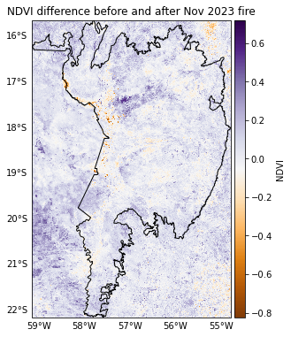

```python
# Compute the difference in NDVI before and after the fire
ndvi_diff = (
    ndvi_da
    .sel(date=slice('2000', '2022'))
    .mean('date')
    .NDVI
    - ndvi_da
    .sel(date='2023')
    .mean('date')
    .NDVI
)

hvplot.extension('matplotlib')  # plotly | matplotlib | bokeh

# Plot the difference
X = (
    ndvi_diff.hvplot(x='x', y='y', cmap='PuOr', geo=True, width=500, height=1000,
                     title="NDVI difference before and after Nov 2023 fire")
    *
    gdf_pant.hvplot(geo=True, facecolor='none')
    )
X
```

# Is the NDVI lower within the fire boundary after the fire?

> **Tasks**
- Check the variable names
- Make sure that the code uses **your** boundary `GeoDataFrame`

```python
out_gdf = (
    gpd.GeoDataFrame(geometry=gdf_pant.envelope)
    .overlay(gdf_pant, how='difference'))
out_gdf
```

|  | geometry |
| --- | --- |
| 0 | MULTIPOLYGON (((-59.14083 -22.16155, -59.14083... |

> ** Tasks**
- Clip your DataArray to the boundaries for both inside and outside the reservation.
- Replace the `GeoDataFrame` name with **your** own.

```python
# Clip data to both inside and outside the boundary
# from_disk=True --> use less memory resources
ndvi_in_da = ndvi_da.rio.clip(gdf_pant.geometry, from_disk=True)
ndvi_out_da = ndvi_da.rio.clip(out_gdf.geometry, from_disk=True)
```

> **Tasks**

> For **both inside and outside** the fire boundary:
> - Group the data by year
> - Take the mean. You always need to tell reducing methods in `xarray` what dimensions you want to reduce. When you want to summarize data across **all** dimensions, you can use the `...` syntax, e.g. `.mean(...)` as a shorthand.
> - Select the NDVI variable
> - Convert to a DataFrame using the `to_dataframe()` method
> - Join the two DataFrames for plotting using the `.join()` method. You will need to rename the columns using the `lsuffix=` and `rsuffix=` parameters
> - Plot annual Nov means for both inside and outside the Reservation on the same plot.

```python
# Compute mean annual Nov NDVI
nov_ndvi_in_df = (
    ndvi_in_da
    .groupby(ndvi_in_da.date.dt.year)
    .mean(...)
    .NDVI.to_dataframe())

nov_ndvi_out_df = (
    ndvi_out_da
    .groupby(ndvi_out_da.date.dt.year)
    .mean(...)
    .NDVI.to_dataframe())

# Plot inside and outside Pantanal
nov_ndvi_df = (
    nov_ndvi_in_df[['NDVI']]
    .join(
        nov_ndvi_out_df[['NDVI']],
        lsuffix=' Burned Area', rsuffix=' Unburned Area')
)

# + 20KB
nov_ndvi_df.hvplot(
    title='NDVI Nov Time Series for Pantanal boundary')
```

[output not shown]

- In 2002 and in 2023 the whole rectangular area was damaged by the fire.
- From 2000 up to 2014 (except 2002) the burned area was concentrated in Pantanal polygon.
- In 2020 the fire was concentrated within Pantanal polygon.

## Showing the difference between outside and inside Pantanal

```python
# Plot difference inside and outside Pantanal
nov_ndvi_df['difference'] = (
    nov_ndvi_df['NDVI Unburned Area']
    - nov_ndvi_df['NDVI Burned Area'])

# + 16KB
nov_ndvi_df.difference.hvplot(
    title='Difference between NDVI within and outside Pantanal'
)
```

[output not shown]

- In the years 2000, 2005, 2013 and 2020, the fire was concentrated in Pantanal's polygon
- In 2017 there where, practically, no difference between inside and outside Pantanal vegetation.

```python
#%%capture
#%%bash
#jupyter nbconvert *.ipynb --to markdown
#jupyter nbconvert *.ipynb --to html
```